# Dizziness

# 1 Description of DataSchema variable

The description of harmonised variable is the following:

- Short name: `dizziness`
- Variable label: `Dizziness problems when walking on a level surface`
- Variable description: `Dizziness problems when walking on a level surface`
- Domain: `Health status and functional limitations`
- Value type: `categorical`
- Category coding:

| **Code** | **Category Label** |
| --- | --- |
| 0 | Yes |
| 1 | No |

- Category missings:

| **Code** | **Category Label** |
| --- | --- |
| 991 | CAPI/interviewer error |
| 992 | Impute |
| 993 | Disable to measure |
| 994 | Not attempt/not done |
| 995 | Does not answer |
| 996 | Not applicable |
| 997 | Refuse |
| 998 | Do not know |
| 999 | Missing |

# 2 Data process

## 2.1 England

### 2.1.1 Wave 1

#### 2.1.1.1 Study-specific variable description

| **Name** | `hediz` |
| --- | --- |
| **Label** | `How often do you have problems with dizziness when you are walking on a level surface?` |
| **Table name** | `wave_1_core_data_v3` |
| **Categories** | `1 = Always; 2 = Very often; 3 = Often; 4 = Sometimes; 5 = Never; 6 = SPONTANEOUS: Never walks; 7 = SPONTANEOUS: Can't walk` |
| **Missings** | `-9 = Refusal; -8 = Don't Know; -1 = Not applicable` |
| **Description** |  |

hediz

| Sample size | Missing values |
| --- | --- |
| 12099 | 413 |

Category

|  | 1 | 2 | 3 | 4 | 5 | 6 | 7 |
| --- | --- | --- | --- | --- | --- | --- | --- |
| Frequency | 73.0 | 99.00 | 144.00 | 1292.00 | 10066.0 | 9.00 | 3.00 |
| Percentage | 0.6 | 0.82 | 1.19 | 10.68 | 83.2 | 0.07 | 0.02 |

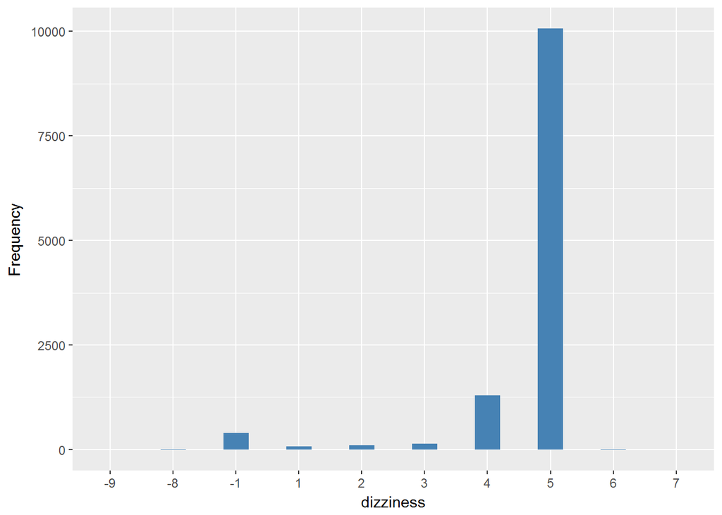

#### 2.1.1.2 Harmonisation algorithm

To compute the harmonize variable from the study-specific variable it has to be recoded as follows:

- `1 Always into 0`
- `2 Very often into 0`
- `3 Often into 0`
- `4 Sometimes into 0`
- `5 Never into 1`
- `6 SPONTANEOUS: Never walks into 996`
- `7 SPONTANEOUS: Can't walk into 996`
- `-9 Refusal into 997`
- `-8 Don't know into 998`
- `-1 Not applicable into 996`

**R script:**

```r
ELSA_ds_w1 <- tibble(id = ELSA_w1_dizziness$id)
ELSA_ds_w1$dizziness <- car::recode(ELSA_w1_dizziness$hediz, "1 = '0';2 = '0';3 = '0';4 = '0';5 = '1';6 = '996';7 = '996';-9 = '997';-8 = '998';-1 = '996' ")
ELSA_ds_w1$dizziness <- labelled(ELSA_ds_w1$dizziness, labels = c(Yes = 0, No = 1,
    Missing = 999, Do_not_know = 998, Refuse = 997, Not_applicable = 996, Does_not_answer = 995,
    Not_attempt_not_done = 994, Disable_to_measure = 993, Impute = 992, CAPI_interviewer_error = 991))
```

#### 2.1.1.3 Statistical description of the new harmonised variable

dizziness

| Sample size | Missing values |
| --- | --- |
| 12099 | 425 |

Category

|  | 0 | 1 |
| --- | --- | --- |
| Frequency | 1608.00 | 10066.0 |
| Percentage | 13.29 | 83.2 |

Type of missing

|  | 991 | 992 | 993 | 994 | 995 | 996 | 997 | 998 | 999 | NA |
| --- | --- | --- | --- | --- | --- | --- | --- | --- | --- | --- |
| Frequency | 0 | 0 | 0 | 0 | 0 | 404.00 | 5.00 | 16.00 | 0 | 0 |
| Percentage | 0 | 0 | 0 | 0 | 0 | 3.34 | 0.04 | 0.13 | 0 | 0 |

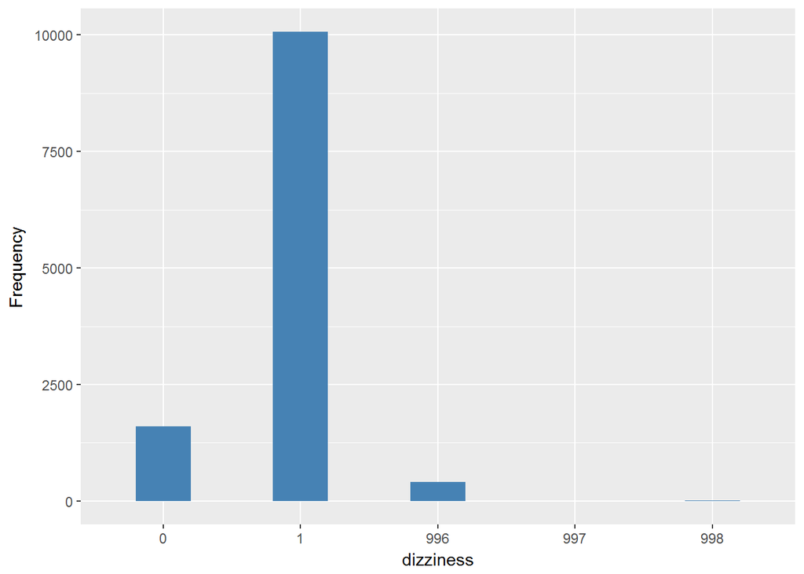

The values coded as 6 and 7 in the study are not missing from its point of view, but are missing for the harmonised variable.

#### 2.1.1.4 Validation

|  | 1,2,3,4->0 | 5->1 | -1,6,7->996 | -9->997 | -8->998 |
| --- | --- | --- | --- | --- | --- |
| BeforeH | 1608 | 10066 | 404 | 5 | 16 |
| AfterH | 1608 | 10066 | 404 | 5 | 16 |

### 2.1.2 Wave 2

#### 2.1.2.1 Study-specific variable description

| **Name** | `HeDiz` |
| --- | --- |
| **Label** | `Dizziness: frequency when walking on level surface` |
| **Table name** | `wave_2_core_data_v4` |
| **Categories** | `1 = Always; 2 = Very often; 3 = Often; 4 = Sometimes; 5 = Never; 6 = SPONTANEOUS: Never walks; 7 = SPONTANEOUS: Can't walk` |
| **Missings** | `-9 = Refusal; -8 = Don't Know; -1 = Not applicable` |
| **Description** |  |

HeDiz

| Sample size | Missing values |
| --- | --- |
| 9432 | 286 |

Category

|  | 1 | 2 | 3 | 4 | 5 | 6 |
| --- | --- | --- | --- | --- | --- | --- |
| Frequency | 44.00 | 71.00 | 102.00 | 1001.00 | 7920.00 | 8.00 |
| Percentage | 0.47 | 0.75 | 1.08 | 10.61 | 83.97 | 0.08 |

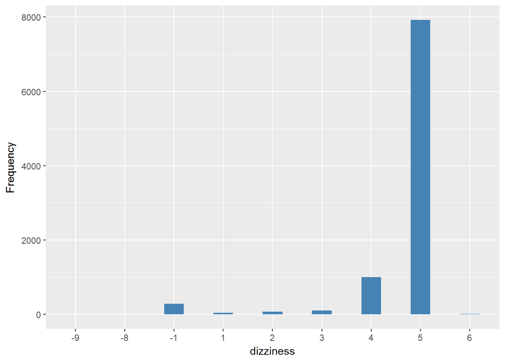

#### 2.1.2.2 Harmonisation algorithm

To compute the harmonize variable from the study-specific variable it has to be recoded as follows:

- `1 Always into 0`
- `2 Very often into 0`
- `3 Often into 0`
- `4 Sometimes into 0`
- `5 Never into 1`
- `6 SPONTANEOUS: Never walks into 996`
- `7 SPONTANEOUS: Can't walk into 996`
- `-9 Refusal into 997`
- `-8 Don't know into 998`
- `-1 Not applicable into 996`

**R script:**

```r
ELSA_ds_w2 <- tibble(id = ELSA_w2_dizziness$id)
ELSA_ds_w2$dizziness <- car::recode(ELSA_w2_dizziness$HeDiz, "1 = '0';2 = '0';3 = '0';4 = '0';5 = '1';6 = '996';7 = '996';-9 = '997';-8 = '998';-1 = '996' ")
ELSA_ds_w2$dizziness <- labelled(ELSA_ds_w2$dizziness, labels = c(Yes = 0, No = 1,
    Missing = 999, Do_not_know = 998, Refuse = 997, Not_applicable = 996, Does_not_answer = 995,
    Not_attempt_not_done = 994, Disable_to_measure = 993, Impute = 992, CAPI_interviewer_error = 991))
```

#### 2.1.2.3 Statistical description of the new harmonised variable

dizziness

| Sample size | Missing values |
| --- | --- |
| 9432 | 294 |

Category

|  | 0 | 1 |
| --- | --- | --- |
| Frequency | 1218.00 | 7920.00 |
| Percentage | 12.91 | 83.97 |

Type of missing

|  | 991 | 992 | 993 | 994 | 995 | 996 | 997 | 998 | 999 | NA |
| --- | --- | --- | --- | --- | --- | --- | --- | --- | --- | --- |
| Frequency | 0 | 0 | 0 | 0 | 0 | 292.0 | 1.00 | 1.00 | 0 | 0 |
| Percentage | 0 | 0 | 0 | 0 | 0 | 3.1 | 0.01 | 0.01 | 0 | 0 |

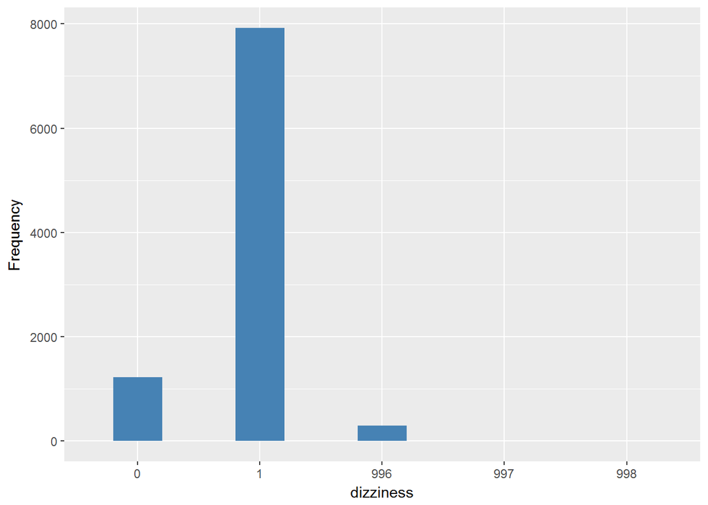

The values coded as 6 and 7 in the study are not missing from its point of view, but are missing for the harmonised variable.

#### 2.1.2.4 Validation

|  | 1,2,3,4->0 | 5->1 | -1,6,7->996 | -9->997 | -8->998 |
| --- | --- | --- | --- | --- | --- |
| BeforeH | 1218 | 7920 | 292 | 1 | 1 |
| AfterH | 1218 | 7920 | 292 | 1 | 1 |

### 2.1.3 Wave 3

Not found.

### 2.1.4 Wave 4

#### 2.1.4.1 Study-specific variable description

| **Name** | `hediz` |
| --- | --- |
| **Label** | `Dizziness: How often respondent has problems with dizziness when walking on level surface` |
| **Table name** | `wave_4_elsa_data_v3` |
| **Categories** | `1 = Always; 2 = Very often; 3 = Often; 4 = Sometimes; 5 = Never; 6 = SPONTANEOUS: Never walks; 7 = SPONTANEOUS: Can't walk` |
| **Missings** | `-9 = Refusal; -8 = Don't Know; -1 = Not applicable` |
| **Description** |  |

hediz

| Sample size | Missing values |
| --- | --- |
| 11050 | 587 |

Category

|  | 1 | 2 | 3 | 4 | 5 | 6 | 7 |
| --- | --- | --- | --- | --- | --- | --- | --- |
| Frequency | 72.00 | 77.0 | 136.00 | 1122.00 | 9047.00 | 8.00 | 1.00 |
| Percentage | 0.65 | 0.7 | 1.23 | 10.15 | 81.87 | 0.07 | 0.01 |

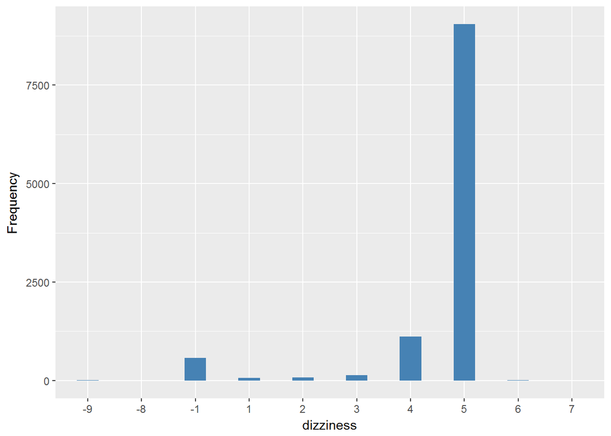

#### 2.1.4.2 Harmonisation algorithm

To compute the harmonize variable from the study-specific variable it has to be recoded as follows:

- `1 Always into 0`
- `2 Very often into 0`
- `3 Often into 0`
- `4 Sometimes into 0`
- `5 Never into 1`
- `6 SPONTANEOUS: Never walks into 996`
- `7 SPONTANEOUS: Can't walk into 996`
- `-9 Refusal into 997`
- `-8 Don't know into 998`
- `-1 Not applicable into 996`

**R script:**

```r
ELSA_ds_w4 <- tibble(id = ELSA_w4_dizziness$id)
ELSA_ds_w4$dizziness <- car::recode(ELSA_w4_dizziness$hediz, "1 = '0';2 = '0';3 = '0';4 = '0';5 = '1';6 = '996';7 = '996';-9 = '997';-8 = '998';-1 = '996' ")
ELSA_ds_w4$dizziness <- labelled(ELSA_ds_w4$dizziness, labels = c(Yes = 0, No = 1,
    Missing = 999, Do_not_know = 998, Refuse = 997, Not_applicable = 996, Does_not_answer = 995,
    Not_attempt_not_done = 994, Disable_to_measure = 993, Impute = 992, CAPI_interviewer_error = 991))
```

#### 2.1.4.3 Statistical description of the new harmonised variable

dizziness

| Sample size | Missing values |
| --- | --- |
| 11050 | 596 |

Category

|  | 0 | 1 |
| --- | --- | --- |
| Frequency | 1407.00 | 9047.00 |
| Percentage | 12.73 | 81.87 |

Type of missing

|  | 991 | 992 | 993 | 994 | 995 | 996 | 997 | 998 | 999 | NA |
| --- | --- | --- | --- | --- | --- | --- | --- | --- | --- | --- |
| Frequency | 0 | 0 | 0 | 0 | 0 | 587.00 | 6.00 | 3.00 | 0 | 0 |
| Percentage | 0 | 0 | 0 | 0 | 0 | 5.31 | 0.05 | 0.03 | 0 | 0 |

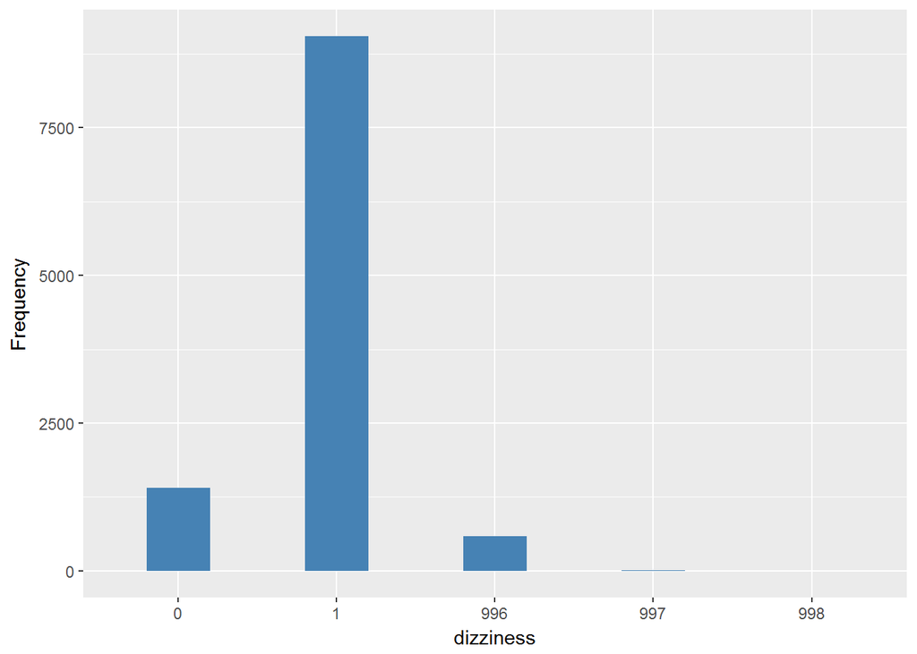

The values coded as 6 and 7 in the study are not missing from its point of view, but are missing for the harmonised variable.

#### 2.1.4.4 Validation

|  | 1,2,3,4->0 | 5->1 | -1,6,7->996 | -9->997 | -8->998 |
| --- | --- | --- | --- | --- | --- |
| BeforeH | 1407 | 9047 | 587 | 6 | 3 |
| AfterH | 1407 | 9047 | 587 | 6 | 3 |

### 2.1.5 Wave 5

Not found.

### 2.1.6 Wave 6

Not found.

### 2.1.7 Wave 7

#### 2.1.7.1 Study-specific variable description

| **Name** | `HeDiz` |
| --- | --- |
| **Label** | `Dizziness: How often respondent has problems with dizziness when walking on level surface` |
| **Table name** | `wave_7_elsa_data` |
| **Categories** | `1 = Always; 2 = Very often; 3 = Often; 4 = Sometimes; 5 = Never; 6 = SPONTANEOUS: Never walks; 7 = SPONTANEOUS: Can't walk` |
| **Missings** | `-8 = Don't Know; -1 = Not applicable` |
| **Description** |  |

HeDiz

| Sample size | Missing values |
| --- | --- |
| 9666 | 723 |

Category

|  | 1 | 2 | 3 | 4 | 5 | 6 | 7 |
| --- | --- | --- | --- | --- | --- | --- | --- |
| Frequency | 65.00 | 87.0 | 119.00 | 919.00 | 7744.00 | 8.00 | 1.00 |
| Percentage | 0.67 | 0.9 | 1.23 | 9.51 | 80.12 | 0.08 | 0.01 |

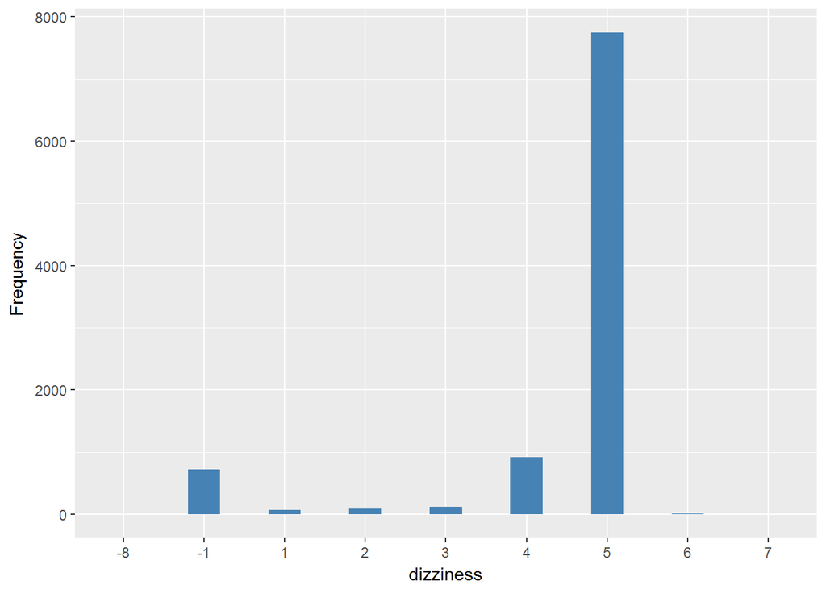

#### 2.1.7.2 Harmonisation algorithm

To compute the harmonize variable from the study-specific variable it has to be recoded as follows:

- `1 Always into 0`
- `2 Very often into 0`
- `3 Often into 0`
- `4 Sometimes into 0`
- `5 Never into 1`
- `6 SPONTANEOUS: Never walks into 996`
- `7 SPONTANEOUS: Can't walk into 996`
- `-8 Don't know into 998`
- `-1 Not applicable into 996`

**R script:**

```r
ELSA_ds_w7 <- tibble(id = ELSA_w7_dizziness$id)
ELSA_ds_w7$dizziness <- car::recode(ELSA_w7_dizziness$HeDiz, "1 = '0';2 = '0';3 = '0';4 = '0';5 = '1';6 = '996';7 = '996';-9 = '997';-8 = '998';-1 = '996' ")
ELSA_ds_w7$dizziness <- labelled(ELSA_ds_w7$dizziness, labels = c(Yes = 0, No = 1,
    Missing = 999, Do_not_know = 998, Refuse = 997, Not_applicable = 996, Does_not_answer = 995,
    Not_attempt_not_done = 994, Disable_to_measure = 993, Impute = 992, CAPI_interviewer_error = 991))
```

#### 2.1.7.3 Statistical description of the new harmonised variable

dizziness

| Sample size | Missing values |
| --- | --- |
| 9666 | 732 |

Category

|  | 0 | 1 |
| --- | --- | --- |
| Frequency | 1190.00 | 7744.00 |
| Percentage | 12.31 | 80.12 |

Type of missing

|  | 991 | 992 | 993 | 994 | 995 | 996 | 997 | 998 | 999 | NA |
| --- | --- | --- | --- | --- | --- | --- | --- | --- | --- | --- |
| Frequency | 0 | 0 | 0 | 0 | 0 | 729.00 | 0 | 3.00 | 0 | 0 |
| Percentage | 0 | 0 | 0 | 0 | 0 | 7.54 | 0 | 0.03 | 0 | 0 |

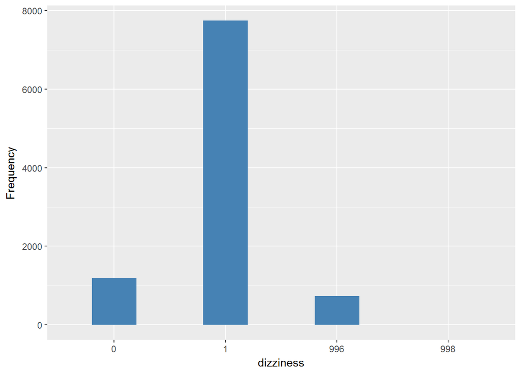

The values coded as 6 and 7 in the study are not missing from its point of view, but are missing for the harmonised variable.

#### 2.1.7.4 Validation

|  | 1,2,3,4->0 | 5->1 | -1,6,7->996 | -8->998 |
| --- | --- | --- | --- | --- |
| BeforeH | 1190 | 7744 | 729 | 3 |
| AfterH | 1190 | 7744 | 729 | 3 |

## 2.2 Summary of descriptive statistics of the harmonised variable accross populations and waves

Two tables are generated:

1. Percentages of categories in each harmonised variable.
2. Frequencies and percentages of individuals with different trajectories. To avoid too large table, Only trajectories with percentages larger than 0.3 are shown.

**R script:**

```r
ELSA_ds_w1$dizziness <- labelled(ELSA_ds_w1$dizziness, labels = c(Presence = 0,
    Absence = 1, Missing = 999, Do_not_know = 998, Refuse = 997, Not_applicable = 996,
    Does_not_answer = 995, Not_attempt_not_done = 994, Disable_to_measure = 993,
    Impute = 992, CAPI_interviewer_error = 991))
ELSA_ds_w2$dizziness <- labelled(ELSA_ds_w2$dizziness, labels = c(Presence = 0,
    Absence = 1, Missing = 999, Do_not_know = 998, Refuse = 997, Not_applicable = 996,
    Does_not_answer = 995, Not_attempt_not_done = 994, Disable_to_measure = 993,
    Impute = 992, CAPI_interviewer_error = 991))
ELSA_ds_w4$dizziness <- labelled(ELSA_ds_w4$dizziness, labels = c(Presence = 0,
    Absence = 1, Missing = 999, Do_not_know = 998, Refuse = 997, Not_applicable = 996,
    Does_not_answer = 995, Not_attempt_not_done = 994, Disable_to_measure = 993,
    Impute = 992, CAPI_interviewer_error = 991))
ELSA_ds_w7$dizziness <- labelled(ELSA_ds_w7$dizziness, labels = c(Presence = 0,
    Absence = 1, Missing = 999, Do_not_know = 998, Refuse = 997, Not_applicable = 996,
    Does_not_answer = 995, Not_attempt_not_done = 994, Disable_to_measure = 993,
    Impute = 992, CAPI_interviewer_error = 991))

tt <- frq(ELSA_ds_w1$dizziness)[[1]][, c(1:2, 4)]
tt[4] <- frq(ELSA_ds_w2$dizziness)[[1]][, c(4)]
tt[5] <- frq(ELSA_ds_w4$dizziness)[[1]][, c(4)]
tt[6] <- frq(ELSA_ds_w7$dizziness)[[1]][, c(4)]
tt[13, ] <- c("n", "sample size", length(ELSA_ds_w1$dizziness), length(ELSA_ds_w2$dizziness),
    length(ELSA_ds_w4$dizziness), length(ELSA_ds_w7$dizziness))
names(tt) <- c("val", "label", "w1", "w2", "w4", "w7")
kable(tt)
```

| val | label | w1 | w2 | w4 | w7 |
| --- | --- | --- | --- | --- | --- |
| 0 | Presence | 13.29 | 12.91 | 12.73 | 12.31 |
| 1 | Absence | 83.2 | 83.97 | 81.87 | 80.12 |
| 991 | CAPI_interviewer_error | 0 | 0 | 0 | 0 |
| 992 | Impute | 0 | 0 | 0 | 0 |
| 993 | Disable_to_measure | 0 | 0 | 0 | 0 |
| 994 | Not_attempt_not_done | 0 | 0 | 0 | 0 |
| 995 | Does_not_answer | 0 | 0 | 0 | 0 |
| 996 | Not_applicable | 3.34 | 3.1 | 5.31 | 7.54 |
| 997 | Refuse | 0.04 | 0.01 | 0.05 | 0 |
| 998 | Do_not_know | 0.13 | 0.01 | 0.03 | 0.03 |
| 999 | Missing | 0 | 0 | 0 | 0 |
| NA | NA | 0 | 0 | 0 | 0 |
| n | sample size | 12099 | 9432 | 11050 | 9666 |

```r
dbb <- merge(ELSA_m_ds_w1, ELSA_m_ds_w2, by = "id", suffixes = c(".w1", ".w2"),
    all = T)
dbb <- merge(dbb, ELSA_m_ds_w4, by = "id", suffixes = c(".w3", ".w4"), all = T)
dbb <- merge(dbb, ELSA_m_ds_w7, by = "id", all = T)
names(dbb) <- c("id", "w1", "w2", "w4", "w7")
v.dbb <- paste(dbb[, 2], dbb[, 3], dbb[, 4], dbb[, 5], sep = "")
f.dbb <- frq(v.dbb)[[1]][, c(1, 2, 4)]
kable(f.dbb[f.dbb[, 3] >= 0.3, ])
```

|  | val | frq | raw.prc |
| --- | --- | --- | --- |
| 1 | 0000 | 79 | 0.44 |
| 3 | 000NA | 87 | 0.49 |
| 5 | 0011 | 56 | 0.31 |
| 9 | 00NANA | 200 | 1.12 |
| 12 | 010NA | 62 | 0.35 |
| 14 | 0111 | 116 | 0.65 |
| 15 | 011NA | 81 | 0.46 |
| 18 | 01NANA | 178 | 1.00 |
| 27 | 0NANANA | 441 | 2.48 |
| 30 | 100NA | 73 | 0.41 |
| 32 | 1011 | 106 | 0.60 |
| 33 | 101NA | 96 | 0.54 |
| 36 | 10NANA | 237 | 1.33 |
| 37 | 1100 | 80 | 0.45 |
| 38 | 1101 | 151 | 0.85 |
| 39 | 110NA | 159 | 0.89 |
| 40 | 1110 | 289 | 1.62 |
| 41 | 1111 | 3160 | 17.76 |
| 42 | 111NA | 1303 | 7.32 |
| 44 | 11NA1 | 177 | 0.99 |
| 45 | 11NANA | 1841 | 10.35 |
| 50 | 1NA11 | 147 | 0.83 |
| 51 | 1NA1NA | 127 | 0.71 |
| 53 | 1NANA1 | 66 | 0.37 |
| 54 | 1NANANA | 1860 | 10.45 |
| 68 | NA1NANA | 88 | 0.49 |
| 69 | NANA00 | 122 | 0.69 |
| 70 | NANA01 | 155 | 0.87 |
| 71 | NANA0NA | 178 | 1.00 |
| 72 | NANA10 | 192 | 1.08 |
| 73 | NANA11 | 2083 | 11.71 |
| 74 | NANA1NA | 1035 | 5.82 |
| 75 | NANANA0 | 183 | 1.03 |
| 76 | NANANA1 | 1304 | 7.33 |
| 77 | NANANANA | 650 | 3.65 |

# 3 Quality estimation

No comments.